# Evaluating the Global Impact of Chronic Respiratory Diseases: A Comprehensive Analysis of Environmental Risk Factors

Daphney Loka

2023-10-20

```r
library(dplyr)

library(tidyverse)

library(readxl)
```

# 1 **Topic Description**

**Chronic respiratory diseases (CRD)** have become a global concern, ranking as the third leading cause of global mortality (Emerson Augusto Baptista, Sudeshna Dey, and Soumya Pal 2021), with four million deaths in 2019 (GBD 2019 Chronic Respiratory Diseases Collaborators 2019). Approximately 7.4% of the world’s population (545 million people) grapple with CRD, significantly impacting their daily lives and life expectancy (GBD Chronic Respiratory Disease Collaborators 2020). It is imperative to understand the incidence, morbidity, and mortality patterns of CRD on both a **global and regional scale**. Despite its widespread impact, CRD has received less public attention and research funding compared to other well-known diseases (Wassim W Labaki and MeiLan K Han 2020). This study aims to investigate environmental risk factors related to air pollution, which directly or indirectly trigger incurable CRD symptoms. It will provide insights into the broader implications of CRD and will help guide preventive measures, screening, treatment, research activities, and enhance public awareness of the disease’s severity (Wassim W Labaki and MeiLan K Han 2020). This study’s focus is on CRD as a whole, rather than solely on one specific type of CRD.

# 2 **Data Acquisition**

## 2.1 Variables Used

Dependent, Independent, and Control Variables Description

Variables

Description

Measurement

Data source

Dependent (Target)

Death rate from Chronic Respiratory Disease (CRD)

Long-term conditions that damage the lungs and airways, with symptoms of coughing, shortness of breath, and decreased lung function, affecting the body’s ability to receive enough oxygen, and hence, influence people’s daily activities and overall well-being

It is measured per 100,000 people

- Country, Code, Year, CRD death rate (age and gender standardised)

Numeric

(Our World in Data 2021)

Independent 1

Forest Area

The land under natural or planted stands of trees, either productive or not, that reaches at least 5 metres height in situ. It does not include trees in urban parks, gardens and tree stands in agricultural production systems (such as in fruit plantations and agroforestry systems)

It is measured by % of land area of a country

- Country, Code, 2015-2019 Forest area

Numeric

(World Bank 2023)

Independent 2

Concentrations of Fine Particulate Matter (PM2.5)

The annual mean of fine particulate matter (PM2.5), which includes sulphate, nitrates, and black carbon) that poses a greater health risk as it may enter deeper into the lungs

- Country, Code, Fact Numeric Value (PM2.5)

Numeric

(World Health Organization 2023)

Independent 3

Share of Adults who smoke

It measures the smoking prevalence based on % of adults (men and women aged 15 and older ) who smoke any tobacco product (excluding smokeless tobacco use) on a daily basis.

- Entity, Code, Year, Prevalance of current tobacco use of adults

Numeric

(Our World in Data 2023)

Independent 4

CO2 Emission

The annual quantity of carbon dioxide (CO2) emitted from fossil fuels burning (coal, oil, gas) directly industrial processes such as cement and steel production. Fossil emissions do not include land use change, deforestation, soils, and vegetation.

- Entity, Code, Year, Annual CO2 Emission

Numeric

(Our World in Data 2022)

Control variable

Region & Income

- Include each country’s regions (either South Asia, Europe & Central Asia, Middle East & North Africa, East Asia & Pacific, Sub-Saharan Africa, Latin America & Caribbean, or North America)
- Include the income level of each country (either Low income, Lower-middle income, Upper-middle income, or High income)

Categorical

(The World Bank 2022)

## 2.2 Base Data

These country-level datasets have a common country/entity and code variable. Due to the variety in some country’s names, it is unsuitable to use “Country” as our primary key. Hence we will be using **“Code”** as our **primary key**, due to the consistent 3 letter country code.

## 2.3 Initial Overview

To assess the impact of environmental and air pollution factors on the death rate of chronic respiratory diseases (CRD), we selected four key independent variables: **Forest area, fine particulate matter (PM2.5) concentrations, adult smoking prevalence, and carbon dioxide emissions**. Outdoor and indoor pollution are common risk factors for CRD, according to the World Health Organization World Health Organization (n.d.) . **Particulate matter (PM)**, arising from industrial emissions, waste combustion, and transportation, is one contributor to outdoor pollution (Xu-Qin Jiang, Xiao-Dong Mei, and Di Feng 2016). Whereas, **smoking** is a significant factor in indoor pollution (Xu-Qin Jiang, Xiao-Dong Mei, and Di Feng 2016). Additionally, living near **forests** has been linked to asthma-related allergic symptoms (Giulia Squillacioti et al. 2017). The burning of fossil fuels, producing compounds like **CO2**, can exacerbate lung inflammation and affect COPD patients’ lung function (Xu-Qin Jiang, Xiao-Dong Mei, and Di Feng 2016). These datasets, along with the CRD death rate, were sourced from the World Bank and Our World in Data, albeit in an unstructured form. Using the `glimpse()` function, we observed that each dataset includes country, code, year, and variable values.

```r
#Dependent - CRD Death rate
respiratory <- read.csv("D:\\SEM 2 2023\\ETW3483 (Mon)\\DaphneyLoka_32685327_IA4\\data\\respiratory-disease-death-rate.csv")
glimpse(respiratory)
```

```
## Rows: 6,840
## Columns: 4
## $ Entity                                                                           <chr> …
## $ Code                                                                             <chr> …
## $ Year                                                                             <int> …
## $ Deaths...Chronic.respiratory.diseases...Sex..Both...Age..Age.standardized..Rate. <dbl> …
```

```r
#Independent 1 - Forest area
forest <- read_xlsx("D:\\SEM 2 2023\\ETW3483 (Mon)\\DaphneyLoka_32685327_IA4\\data\\Forest Area (2015-2019).xlsx")
glimpse(forest)
```

```
## Rows: 266
## Columns: 9
## $ `Series Name`   <chr> "Forest area (% of land area)", "Forest area (% of lan…
## $ `Series Code`   <chr> "AG.LND.FRST.ZS", "AG.LND.FRST.ZS", "AG.LND.FRST.ZS", …
## $ `Country Name`  <chr> "Afghanistan", "Albania", "Algeria", "American Samoa",…
## $ `Country Code`  <chr> "AFG", "ALB", "DZA", "ASM", "AND", "AGO", "ATG", "ARG"…
## $ `2015 [YR2015]` <chr> "1.85278199408184", "28.802463503649602", "0.821247986…
## $ `2016 [YR2016]` <chr> "1.85278199408184", "28.802189781021902", "0.821247986…
## $ `2017 [YR2017]` <chr> "1.85278199408184", "28.7920620437956", "0.81578979410…
## $ `2018 [YR2018]` <chr> "1.85278199408184", "28.7919708029197", "0.81033160196…
## $ `2019 [YR2019]` <chr> "1.85278199408184", "28.7919708029197", "0.81411035036…
```

```r
#Independent 2 - Concentrations of Fine Particulate Matter
PM <- read_xlsx("D:\\SEM 2 2023\\ETW3483 (Mon)\\DaphneyLoka_32685327_IA4\\data\\Concentrations of fine particulate matter.xlsx")
glimpse(PM)
```

```
## Rows: 975
## Columns: 34
## $ IndicatorCode              <chr> "SDGPM25", "SDGPM25", "SDGPM25", "SDGPM25",…
## $ Indicator                  <chr> "Concentrations of fine particulate matter …
## $ ValueType                  <chr> "text", "text", "text", "text", "text", "te…
## $ ParentLocationCode         <chr> "AFR", "AFR", "AFR", "AFR", "AFR", "AFR", "…
## $ ParentLocation             <chr> "Africa", "Africa", "Africa", "Africa", "Af…
## $ `Location type`            <chr> "Country", "Country", "Country", "Country",…
## $ SpatialDimValueCode        <chr> "AGO", "AGO", "AGO", "AGO", "AGO", "BDI", "…
## $ Location                   <chr> "Angola", "Angola", "Angola", "Angola", "An…
## $ `Period type`              <chr> "Year", "Year", "Year", "Year", "Year", "Ye…
## $ Period                     <chr> "2019", "2018", "2017", "2016", "2015", "20…
## $ IsLatestYear               <lgl> TRUE, FALSE, FALSE, FALSE, FALSE, TRUE, FAL…
## $ `Dim1 type`                <chr> "Residence Area Type", "Residence Area Type…
## $ Dim1                       <chr> "Total", "Total", "Total", "Total", "Total"…
```

[output cut: 21 more lines]

```r
#Independent 3 - share of adults smoking
smoking <- read.csv("D:\\SEM 2 2023\\ETW3483 (Mon)\\DaphneyLoka_32685327_IA4\\data\\share-of-adults-who-smoke.csv")
glimpse(smoking)
```

```
## Rows: 1,239
## Columns: 4
## $ Entity                                          <chr> "Afghanistan", "Afghan…
## $ Code                                            <chr> "AFG", "AFG", "AFG", "…
## $ Year                                            <int> 2000, 2005, 2010, 2015…
## $ Prevalence.of.current.tobacco.use....of.adults. <dbl> 36.9, 32.7, 29.1, 26.0…
```

```r
#Independent 4 - CO2 emission
CO2 <- read.csv("D:\\SEM 2 2023\\ETW3483 (Mon)\\DaphneyLoka_32685327_IA4\\data\\annual-co2-emissions-per-country.csv")
glimpse(CO2)
```

```
## Rows: 31,349
## Columns: 4
## $ Entity               <chr> "Afghanistan", "Afghanistan", "Afghanistan", "Afg…
## $ Code                 <chr> "AFG", "AFG", "AFG", "AFG", "AFG", "AFG", "AFG", …
## $ Year                 <int> 1949, 1950, 1951, 1952, 1953, 1954, 1955, 1956, 1…
## $ Annual.CO..emissions <dbl> 14656, 84272, 91600, 91600, 106256, 106256, 15388…
```

```r
#Control variable - Income and Region
income <- read_xlsx("D:\\SEM 2 2023\\ETW3483 (Mon)\\DaphneyLoka_32685327_IA4\\data\\Region & Income level.xlsx")
glimpse(income)
```

```
## Rows: 218
## Columns: 4
## $ Economy        <chr> "Afghanistan", "Albania", "Algeria", "American Samoa", …
## $ Code           <chr> "AFG", "ALB", "DZA", "ASM", "AND", "AGO", "ATG", "ARG",…
## $ Region         <chr> "South Asia", "Europe & Central Asia", "Middle East & N…
## $ `Income group` <chr> "Low income", "Upper Middle income", "Upper Middle inco…
```

# 3 **Data Wrangling**

## 3.1 Tidy data

In our case, all our variables are currently distributed across separate datasets. Before joining them into a single dataset we will tidy them by removing unnecessary columns and standardising the table structure, as outlined below, as our raw datasets lack uniformity which presents challenges. This is to facilitate the subsequent transformation process. Hence, our initial step involves tidying by CRD death and PM datasets exhibit a distinct structure featuring a ‘Year’ column instead of 2015 to 2019 columns, hence we apply `filter` to retain the desired years and employ `pivot` function . The forest dataset contains two redundant columns (‘Series name’ and ‘Series code’) that have been removed. Additionally, the 2015 to 2019 columns were initially identified as character data and were converted to a numeric format. Furthermore, four missing values were detected, which are removed as they correlate to unrecorded in the World Bank dataset.

| Country | Code | 2015 | 2016 | 2017 | 2018 | 2019 |
| --- | --- | --- | --- | --- | --- | --- |
| … | … | … | … | … | … | … |

### 3.1.1 Respiratory

```r
class(respiratory$Deaths...Chronic.respiratory.diseases...Sex..Both...Age..Age.standardized..Rate.)
```

```
## [1] "numeric"
```

```r
#numeric
```

```r
class(respiratory$Year) #integer
```

```
## [1] "integer"
```

```r
#Filter forest data to only 2015 - 2019
respiratory_tidy <- respiratory %>%
  filter(Year %in% c(2015, 2016, 2017, 2018, 2019)) %>%
  rename(CRD_death = "Deaths...Chronic.respiratory.diseases...Sex..Both...Age..Age.standardized..Rate.", Country = "Entity")

#Pivot wider for structure standardisation
respiratory_tidy <- respiratory_tidy %>%
  pivot_wider(names_from = "Year", values_from = "CRD_death")

class(respiratory_tidy$`2015`)
```

```
## [1] "numeric"
```

```r
#together with 2016,2017,2018,2019 all are already numeric
```

```r
glimpse(respiratory_tidy)
```

```
## Rows: 228
## Columns: 7
## $ Country <chr> "Afghanistan", "African Region (WHO)", "Albania", "Algeria", "…
## $ Code    <chr> "AFG", "", "ALB", "DZA", "ASM", "AND", "AGO", "ATG", "ARG", "A…
## $ `2015`  <dbl> 72.11, 46.36, 20.09, 31.88, 59.23, 26.32, 50.06, 12.28, 34.86,…
## $ `2016`  <dbl> 70.90, 45.45, 20.00, 31.36, 58.11, 26.17, 48.88, 12.35, 35.81,…
## $ `2017`  <dbl> 69.95, 44.71, 19.88, 30.95, 58.23, 26.00, 48.05, 12.12, 35.94,…
## $ `2018`  <dbl> 68.95, 43.85, 19.71, 30.65, 58.07, 25.87, 47.41, 11.99, 35.09,…
## $ `2019`  <dbl> 67.82, 43.10, 19.54, 30.36, 57.84, 25.66, 46.92, 11.93, 34.85,…
```

### 3.1.2 Forest

```r
class(forest$`2015 [YR2015]`) #character
```

```
## [1] "character"
```

```r
forest_tidy <- forest %>%
  select(-1, -2) %>%   #remove unnecessary columns
  rename (
    Country = "Country Name",
    Code = "Country Code",
    `2015` = "2015 [YR2015]",
    `2016` = "2016 [YR2016]",
    `2017` = "2017 [YR2017]",
    `2018` = "2018 [YR2018]",
    `2019` = "2019 [YR2019]") %>%
  mutate(across(c(`2015`, `2016`, `2017`, `2018`, `2019`), as.numeric)) %>% #convert to numeric
  mutate_if(is.numeric, round, 2)
```

```r
library(hablar)

forest_tidy %>% find_na() #four NAs
```

```
## # A tibble: 4 × 7
##   Country              Code  `2015` `2016` `2017` `2018` `2019`
##   <chr>                <chr>  <dbl>  <dbl>  <dbl>  <dbl>  <dbl>
## 1 Hong Kong SAR, China HKG       NA     NA     NA     NA     NA
## 2 Kosovo               XKX       NA     NA     NA     NA     NA
## 3 Macao SAR, China     MAC       NA     NA     NA     NA     NA
## 4 Not classified       INX       NA     NA     NA     NA     NA
```

```r
forest_tidy1 <- na.omit(forest_tidy) #remove NAs

forest_tidy1 %>% find_na() #No more NAs
```

```
## # A tibble: 0 × 7
## # ℹ 7 variables: Country <chr>, Code <chr>, 2015 <dbl>, 2016 <dbl>, 2017 <dbl>,
## #   2018 <dbl>, 2019 <dbl>
```

### 3.1.3 Concentrations of Fine PM

```r
class(PM$FactValueNumeric) #numeric
```

```
## [1] "numeric"
```

Is already numeric so no change is needed

```r
PM_tidy <- PM %>%
  select(7, 8, 10, 24) %>%
  rename(Code = "SpatialDimValueCode", Country = "Location", PM_value = "FactValueNumeric", Year = "Period")

PM_tidy <- PM_tidy %>%
  pivot_wider(names_from = "Year", values_from = "PM_value")

glimpse(PM_tidy)
```

```
## Rows: 195
## Columns: 7
## $ Code    <chr> "AGO", "BDI", "BEN", "BFA", "BWA", "CAF", "CIV", "CMR", "COD",…
## $ Country <chr> "Angola", "Burundi", "Benin", "Burkina Faso", "Botswana", "Cen…
## $ `2019`  <dbl> 27.16, 28.00, 31.51, 40.74, 12.82, 27.20, 40.41, 56.37, 31.58,…
## $ `2018`  <dbl> 25.85, 27.98, 32.34, 41.77, 12.95, 28.25, 41.81, 57.80, 31.46,…
## $ `2017`  <dbl> 25.44, 27.63, 32.66, 42.74, 13.11, 27.94, 42.12, 59.30, 31.32,…
## $ `2016`  <dbl> 26.08, 28.37, 32.73, 43.05, 12.69, 29.15, 42.70, 59.20, 32.99,…
## $ `2015`  <dbl> 25.03, 28.37, 33.11, 43.63, 12.89, 29.06, 43.76, 59.09, 32.21,…
```

### 3.1.4 Smoking

```r
class(smoking$Prevalence.of.current.tobacco.use....of.adults.)
```

```
## [1] "numeric"
```

```r
class(smoking$Year) #integer
```

```
## [1] "integer"
```

```r
#Filter forest data to only 2015 - 2019
smoking_tidy <- smoking %>%
  filter(Year %in% c(2015, 2018, 2019)) %>%
  rename(tobacco_use = "Prevalence.of.current.tobacco.use....of.adults.", Country = "Entity")

smoking_tidy <- smoking_tidy %>%
  pivot_wider(names_from = "Year", values_from = "tobacco_use")

class(smoking_tidy$`2015`)
```

```
## [1] "numeric"
```

```r
glimpse(smoking_tidy)
```

```
## Rows: 177
## Columns: 5
## $ Country <chr> "Afghanistan", "Albania", "Algeria", "Andorra", "Argentina", "…
## $ Code    <chr> "AFG", "ALB", "DZA", "AND", "ARG", "ARM", "AUS", "AUT", "AZE",…
## $ `2015`  <dbl> 26.0, 25.1, 21.1, 33.0, 26.6, 26.9, 15.7, 31.2, 25.2, 10.6, 16…
## $ `2018`  <dbl> 23.8, 23.0, 21.0, 32.0, 24.9, 25.8, 14.0, 27.1, 24.2, 10.7, 15…
## $ `2019`  <dbl> 23.8, 23.0, 21.0, 32.0, 24.9, 25.8, 14.0, 27.1, 24.2, 10.7, 15…
```

### 3.1.5 CO2

```r
class(CO2$Annual.CO..emissions)
```

```
## [1] "numeric"
```

```r
class(CO2$Year)
```

```
## [1] "integer"
```

```r
#Filter forest data to only 2015 - 2019
CO2_tidy <- CO2 %>%
  filter(Year %in% c(2015, 2016, 2017, 2018, 2019)) %>%
  rename(Country = "Entity")

#Pivot wider for structure standardisation
CO2_tidy <- CO2_tidy %>%
  pivot_wider(names_from = "Year", values_from = "Annual.CO..emissions") %>%
  filter(Code != "")

class(CO2_tidy$`2015`)
```

```
## [1] "numeric"
```

```r
#together with 2016,2017,2018,2019 all are already numeric
```

```r
glimpse(CO2_tidy)
```

```
## Rows: 220
## Columns: 7
## $ Country <chr> "Afghanistan", "Albania", "Algeria", "Andorra", "Angola", "Ang…
## $ Code    <chr> "AFG", "ALB", "DZA", "AND", "AGO", "AIA", "ATG", "ARG", "ARM",…
## $ `2015`  <dbl> 9791093, 4712137, 160087460, 465328, 25530950, 153888, 479984,…
## $ `2016`  <dbl> 9067598, 4631977, 158748370, 468992, 27209698, 153888, 490976,…
## $ `2017`  <dbl> 9867969, 5564149, 166411380, 465328, 24304090, 142896, 490976,…
## $ `2018`  <dbl> 10818048, 4984045, 173911580, 494640, 22779500, 142896, 498304…
## $ `2019`  <dbl> 11081621, 4947485, 179504830, 479984, 21818020, 153888, 498304…
```

### 3.1.6 Income

```r
income <- income %>%
  rename (Country = "Economy", income_group = `Income group`)
```

## 3.2 Transform data

After tidying we can proceed with calculating the average values of numerical variables over a five-year period, which is the scope of analysis. Subsequently, all the datasets are joined into a single dataset using the `left_join` function, with the **“Code”** in the ‘PM’ dataset as the **base data** due to its 195 observations, aligning with the total number of countries globally. After joining, four of our categorical variables are observed to be labelled as characters by R, which will be converted into factors to enhance usability. The `vis_miss` function contained in visdat package is employed, to identify the location of missing values within our dataset. There are two observations (COK, NIU) that do not contain Country Name, Region, Income, Smoke, and Forest datasets, hence are deemed to be removed. The majority of our missing values are concentrated within the Smoke datasets, while both Forest and CO2 datasets contain two NAs each.

### 3.2.1 Calculating Average of Five Years

```r
#Average of CRD death rate across five years
respiratory_mean <- respiratory_tidy %>%
  group_by(Country, Code) %>%
  summarise(avg_crd_five = mean(`2015`, `2016`, `2017`, `2018`, `2019`)) %>%
  ungroup() %>%
  select(-1)

glimpse(respiratory_mean)
```

```
## Rows: 228
## Columns: 2
## $ Code         <chr> "AFG", "", "ALB", "DZA", "ASM", "AND", "AGO", "ATG", "ARG…
## $ avg_crd_five <dbl> 72.11, 46.36, 20.09, 31.88, 59.23, 26.32, 50.06, 12.28, 3…
```

```r
forest_mean <- forest_tidy1 %>%
  group_by(Country, Code) %>%
  summarise(avg_forest_five = mean(`2015`, `2016`, `2017`, `2018`, `2019`)) %>%
  ungroup() %>%
  select(-1)

glimpse(forest_mean)
```

```
## Rows: 262
## Columns: 2
## $ Code            <chr> "AFG", "AFE", "AFW", "ALB", "DZA", "ASM", "AND", "AGO"…
## $ avg_forest_five <dbl> 1.85, 31.26, 20.23, 28.80, 0.82, 86.40, 34.04, 55.65, …
```

```r
PM_mean <- PM_tidy %>%
  group_by(Country, Code) %>%
  summarise(avg_PM_five = mean(`2015`, `2016`, `2017`, `2018`, `2019`)) %>%
  ungroup() %>%
  select(-1)

glimpse(PM_mean)
```

```
## Rows: 195
## Columns: 2
## $ Code        <chr> "AFG", "ALB", "DZA", "AND", "AGO", "ATG", "ARG", "ARM", "A…
## $ avg_PM_five <dbl> 67.20, 18.98, 22.49, 9.94, 25.03, 8.89, 14.18, 40.59, 6.60…
```

```r
smoking_mean <- smoking_tidy %>%
  mutate_if(is.numeric, round, 2) %>%
  group_by(Country, Code) %>%
  summarise(avg_smoke_five = mean(`2015`, `2018`, `2019`)) %>%
  ungroup() %>%
  select(-1)

glimpse(smoking_mean)
```

```
## Rows: 177
## Columns: 2
## $ Code           <chr> "AFG", "ALB", "DZA", "AND", "ARG", "ARM", "AUS", "AUT",…
## $ avg_smoke_five <dbl> 26.0, 25.1, 21.1, 33.0, 26.6, 26.9, 15.7, 31.2, 25.2, 1…
```

```r
CO2_mean <- CO2_tidy %>%
  group_by(Country, Code) %>%
  summarise(avg_CO2_five = mean(`2015`, `2016`, `2017`, `2018`, `2019`)) %>%
  ungroup() %>%
  select(-1)

glimpse(CO2_mean)
```

```
## Rows: 220
## Columns: 2
## $ Code         <chr> "AFG", "ALB", "DZA", "AND", "AGO", "AIA", "ATG", "ARG", "…
## $ avg_CO2_five <dbl> 9791093, 4712137, 160087460, 465328, 25530950, 153888, 47…
```

### 3.2.2 Joining all datasets

```r
join1 <- left_join(PM_mean, respiratory_mean, by = "Code")

join2 <- left_join(join1, forest_mean, by = "Code")

join3 <- left_join(join2, smoking_mean, by = "Code")

join4 <- left_join(join3, CO2_mean, by = "Code")

join5 <- left_join(join4, income, by = "Code")
```

#### 3.2.2.1 Convert categorical variables as factor

```r
class(join5$Country) #character
```

```
## [1] "character"
```

```r
class(join5$Code) #character
```

```
## [1] "character"
```

```r
class(join5$Region) #character
```

```
## [1] "character"
```

```r
class(join5$income_group) #character
```

```
## [1] "character"
```

```r
join5_factor <- join5 %>%
  mutate(across(where(is.character), as.factor))

glimpse(join5_factor)
```

```
## Rows: 195
## Columns: 9
## $ Code            <fct> AFG, ALB, DZA, AND, AGO, ATG, ARG, ARM, AUS, AUT, AZE,…
## $ avg_PM_five     <dbl> 67.20, 18.98, 22.49, 9.94, 25.03, 8.89, 14.18, 40.59, …
## $ avg_crd_five    <dbl> 72.11, 20.09, 31.88, 26.32, 50.06, 12.28, 34.86, 35.60…
## $ avg_forest_five <dbl> 1.85, 28.80, 0.82, 34.04, 55.65, 19.20, 10.63, 11.57, …
## $ avg_smoke_five  <dbl> 26.0, 25.1, 21.1, 33.0, NA, NA, 26.6, 26.9, 15.7, 31.2…
## $ avg_CO2_five    <dbl> 9791093, 4712137, 160087460, 465328, 25530950, 479984,…
## $ Country         <fct> "Afghanistan", "Albania", "Algeria", "Andorra", "Angol…
## $ Region          <fct> South Asia, Europe & Central Asia, Middle East & North…
## $ income_group    <fct> Low income, Upper Middle income, Upper Middle income, …
```

#### 3.2.2.2 Missing Values

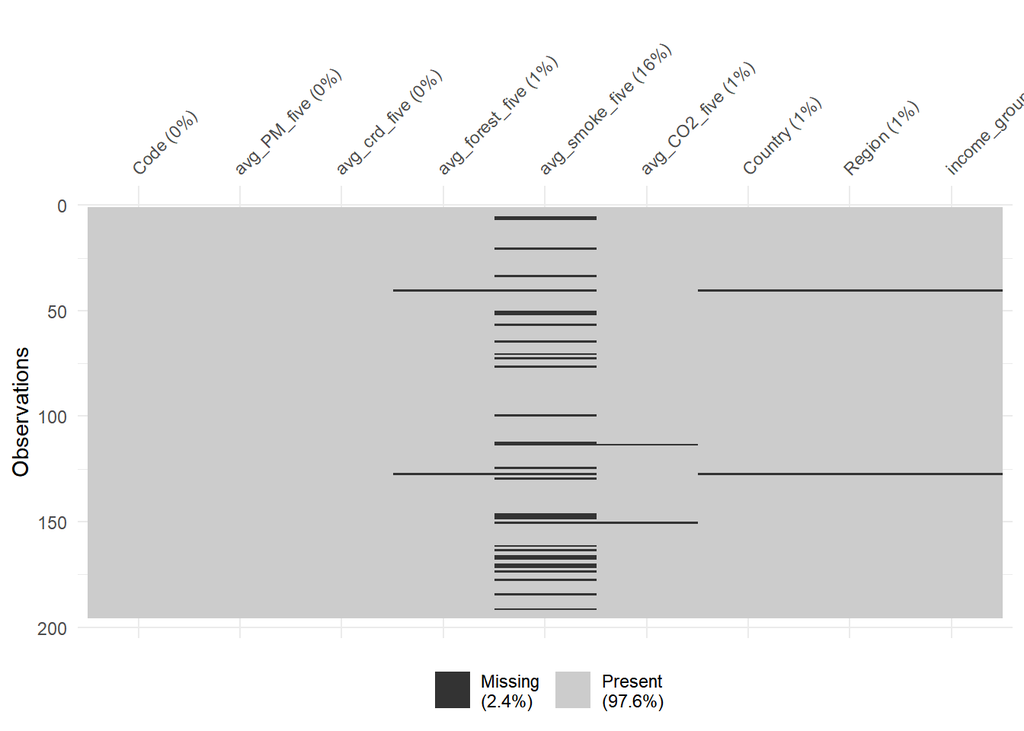

```r
library(visdat)
vis_miss(join5)
```

```r
join5_no <- join5_factor[-c(40, 127),] #remove COK and NIU

final <- join5_no %>% select(7,1,8,9,3,4,2,5,6) %>% #rearrange columns
  mutate_if(is.numeric, round, 2)
```

# 4 **Final Results Presentation**

## 4.1 Final Overview after Tidying and Transforming

```r
glimpse(final)
```

```
## Rows: 193
## Columns: 9
## $ Country         <fct> "Afghanistan", "Albania", "Algeria", "Andorra", "Angol…
## $ Code            <fct> AFG, ALB, DZA, AND, AGO, ATG, ARG, ARM, AUS, AUT, AZE,…
## $ Region          <fct> South Asia, Europe & Central Asia, Middle East & North…
## $ income_group    <fct> Low income, Upper Middle income, Upper Middle income, …
## $ avg_crd_five    <dbl> 72.11, 20.09, 31.88, 26.32, 50.06, 12.28, 34.86, 35.60…
## $ avg_forest_five <dbl> 1.85, 28.80, 0.82, 34.04, 55.65, 19.20, 10.63, 11.57, …
## $ avg_PM_five     <dbl> 67.20, 18.98, 22.49, 9.94, 25.03, 8.89, 14.18, 40.59, …
## $ avg_smoke_five  <dbl> 26.0, 25.1, 21.1, 33.0, NA, NA, 26.6, 26.9, 15.7, 31.2…
## $ avg_CO2_five    <dbl> 9791093, 4712137, 160087460, 465328, 25530950, 479984,…
```

## 4.2 Summary Statistics - Descriptive statistics

```r
library(gtsummary)
```

```r
#Numerical variables by Region
final %>%
  tbl_summary(include = c(avg_crd_five, avg_PM_five, avg_forest_five, avg_smoke_five, avg_CO2_five),
              by = Region,
              missing = "no",
              type = all_continuous() ~ "continuous2",
    statistic = list(all_continuous() ~ c(
      "{median} ({p25}, {p75})",
      "{mean}"), all_categorical() ~ "{n} ({p}%)")) %>%
  add_overall() %>%
  bold_labels()
```

| **Characteristic** | **Overall**, N = 193 | **East Asia & Pacific**, N = 30 | **Europe & Central Asia**, N = 51 | **Latin America & Caribbean**, N = 33 | **Middle East & North Africa**, N = 21 | **North America**, N = 2 | **South Asia**, N = 8 | **Sub-Saharan Africa**, N = 48 |
| --- | --- | --- | --- | --- | --- | --- | --- | --- |
| avg_crd_five |  |  |  |  |  |  |  |  |
| Median (IQR) | 34 (22, 53) | 76 (36, 111) | 21 (16, 30) | 25 (21, 33) | 29 (25, 36) | 31 (28, 35) | 93 (70, 130) | 47 (42, 57) |
| Mean | 44 | 79 | 24 | 28 | 30 | 31 | 109 | 52 |
| avg_PM_five |  |  |  |  |  |  |  |  |
| Median (IQR) | 19 (12, 30) | 11 (7, 21) | 15 (11, 23) | 13 (10, 20) | 30 (24, 44) | 8 (7, 8) | 45 (28, 56) | 29 (17, 39) |
| Mean | 23 | 17 | 18 | 15 | 36 | 8 | 42 | 29 |
| avg_forest_five |  |  |  |  |  |  |  |  |
| Median (IQR) | 31 (11, 51) | 50 (26, 64) | 31 (14, 38) | 48 (32, 58) | 1 (0, 4) | 36 (35, 38) | 19 (5, 36) | 25 (11, 46) |
| Mean | 32 | 47 | 30 | 46 | 3 | 36 | 24 | 31 |
| avg_smoke_five |  |  |  |  |  |  |  |  |
| Median (IQR) | 23 (14, 28) | 26 (23, 37) | 28 (25, 33) | 12 (10, 15) | 20 (16, 25) | 21 (18, 23) | 28 (25, 34) | 13 (9, 17) |
| Mean | 22 | 29 | 28 | 14 | 21 | 21 | 30 | 14 |
| avg_CO2_five |  |  |  |  |  |  |  |  |
| Median (IQR) | 10,788,440 (2,325,785, 66,862,512) | 8,797,431 (210,680, 191,408,850) | 43,777,416 (10,278,881, 103,695,920) | 7,406,021 (2,003,336, 41,275,732) | 58,495,180 (25,734,552, 160,087,460) | 2,975,438,120 (1,774,868,180, 4,176,008,060) | 14,810,688 (5,506,421, 96,470,855) | 3,249,035 (1,026,026, 7,663,796) |
| Mean | 178,243,370 | 457,240,058 | 133,135,763 | 55,889,991 | 127,072,108 | 2,975,438,120 | 318,642,138 | 16,473,586 |

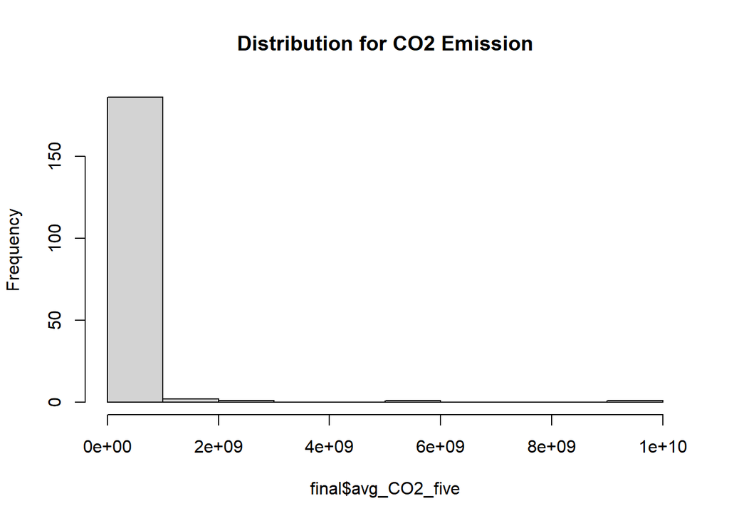

```r
hist(final$avg_CO2_five, main = "Distribution for CO2 Emission")
```

```r
#SEPARATE INCOME ONLY BY REGION
final %>%
  tbl_summary(include = c(Region, income_group),
              by = Region,
              statistic = list(all_categorical() ~ "{n} ({p}%)")) %>%
  add_overall() %>%
  bold_labels()
```

| **Characteristic** | **Overall**, N = 193<sup>1</sup> | **East Asia & Pacific**, N = 30<sup>1</sup> | **Europe & Central Asia**, N = 51<sup>1</sup> | **Latin America & Caribbean**, N = 33<sup>1</sup> | **Middle East & North Africa**, N = 21<sup>1</sup> | **North America**, N = 2<sup>1</sup> | **South Asia**, N = 8<sup>1</sup> | **Sub-Saharan Africa**, N = 48<sup>1</sup> |
| --- | --- | --- | --- | --- | --- | --- | --- | --- |
| income_group |  |  |  |  |  |  |  |  |
| High income | 57 (30%) | 7 (23%) | 31 (61%) | 8 (24%) | 8 (38%) | 2 (100%) | 0 (0%) | 1 (2.1%) |
| Low income | 34 (18%) | 1 (3.3%) | 1 (2.0%) | 1 (3.0%) | 2 (9.5%) | 0 (0%) | 2 (25%) | 27 (56%) |
| Lower Middle income | 46 (24%) | 13 (43%) | 5 (9.8%) | 4 (12%) | 5 (24%) | 0 (0%) | 5 (63%) | 14 (29%) |
| Upper Middle income | 56 (29%) | 9 (30%) | 14 (27%) | 20 (61%) | 6 (29%) | 0 (0%) | 1 (13%) | 6 (13%) |

<sup>1</sup> n (%)

## 4.3 Predictive Modelling

### 4.3.1 Data Splitting

```r
#packages
library(rsample)
library(recipes)
library(caret)
```

```r
set.seed(123)
split <- initial_split(final, strata = "avg_crd_five")
final_train <- training(split)
final_test <- testing(split)
```

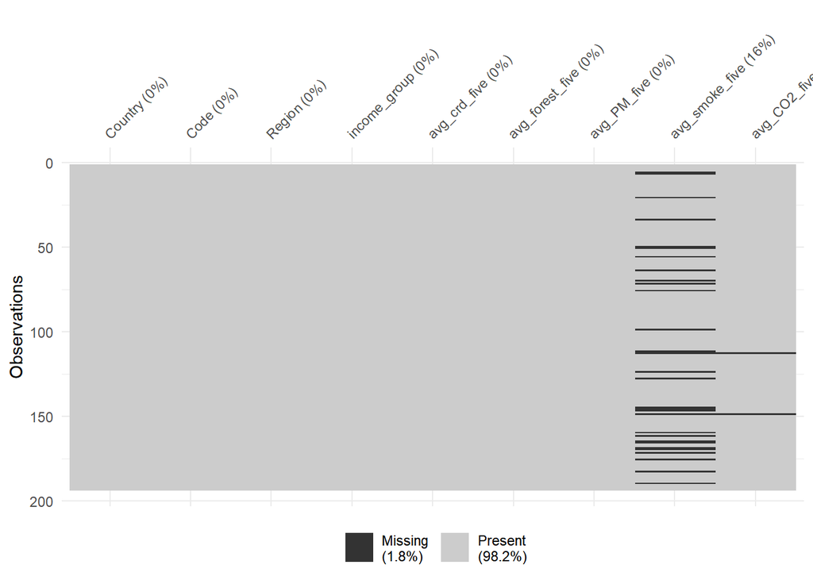

```r
#Plotting missing datas (NAs)
vis_miss(final)
```

### 4.3.2 Blueprint 1 (Log(CO2))

```r
final_recipe1 <- recipe(avg_crd_five ~ ., data = final_train) %>%
  step_log(avg_CO2_five) %>%      #normalize with a log transformation
  step_impute_median(avg_smoke_five, avg_CO2_five) %>%   #median imputation of NAs
  step_dummy(Region, income_group)

prepare1 <- prep(final_recipe1, training = final_train)

baked_train1 <- bake(prepare1, new_data = final_train)
baked_test1 <- bake(prepare1, new_data = final_test)
```

```r
baked_train1
```

```
## # A tibble: 144 × 16
##    Country        Code  avg_forest_five avg_PM_five avg_smoke_five avg_CO2_five
##    <fct>          <fct>           <dbl>       <dbl>          <dbl>        <dbl>
##  1 Austria        AUT              47.0       13.6            31.2         18.0
##  2 Bahamas, The   BHS              50.9        5.32           10.6         14.6
##  3 Barbados       BRB              14.6       10.5             8.8         14.1
##  4 Bulgaria       BGR              35.3       20.4            40.7         17.7
##  5 Cabo Verde     CPV              11.0       33.4            13.1         13.1
##  6 Croatia        HRV              34.3       18.6            36.1         16.7
##  7 Czech Republic CZE              34.6       17.5            31.4         18.5
##  8 Estonia        EST              55.7        6.75           33.3         16.6
##  9 Finland        FIN              73.7        5.83           24.5         17.6
## 10 France         FRA              30.8       12.2            33.7         19.6
## # ℹ 134 more rows
## # ℹ 10 more variables: avg_crd_five <dbl>, Region_Europe...Central.Asia <dbl>,
## #   Region_Latin.America...Caribbean <dbl>,
## #   Region_Middle.East...North.Africa <dbl>, Region_North.America <dbl>,
## #   Region_South.Asia <dbl>, Region_Sub.Saharan.Africa <dbl>,
## #   income_group_Low.income <dbl>, income_group_Lower.Middle.income <dbl>,
## #   income_group_Upper.Middle.income <dbl>
```

```r
baked_test1
```

```
## # A tibble: 49 × 16
##    Country         Code  avg_forest_five avg_PM_five avg_smoke_five avg_CO2_five
##    <fct>           <fct>           <dbl>       <dbl>          <dbl>        <dbl>
##  1 Afghanistan     AFG              1.85       67.2            26           16.1
##  2 Albania         ALB             28.8        19.0            25.1         15.4
##  3 Algeria         DZA              0.82       22.5            21.1         18.9
##  4 Angola          AGO             55.6        25.0            23.0         17.1
##  5 Antigua and Ba… ATG             19.2         8.89           23.0         13.1
##  6 Australia       AUS             17.3         6.6            15.7         19.8
##  7 Belarus         BLR             42.5        16.5            33           17.9
##  8 Cameroon        CMR             43.6        59.1             8.4         16.1
##  9 Colombia        COL             54.2        17.3             9.9         18.4
## 10 Cyprus          CYP             18.7        15.1            36.4         15.8
## # ℹ 39 more rows
## # ℹ 10 more variables: avg_crd_five <dbl>, Region_Europe...Central.Asia <dbl>,
## #   Region_Latin.America...Caribbean <dbl>,
## #   Region_Middle.East...North.Africa <dbl>, Region_North.America <dbl>,
## #   Region_South.Asia <dbl>, Region_Sub.Saharan.Africa <dbl>,
## #   income_group_Low.income <dbl>, income_group_Lower.Middle.income <dbl>,
## #   income_group_Upper.Middle.income <dbl>
```

```r
cor(baked_train1[c("avg_crd_five", "avg_forest_five", "avg_PM_five", "avg_smoke_five", "avg_CO2_five")])
```

```
##                 avg_crd_five avg_forest_five avg_PM_five avg_smoke_five
## avg_crd_five       1.0000000      0.15063637   0.1462156     0.17574111
## avg_forest_five    0.1506364      1.00000000  -0.4090858     0.02941778
## avg_PM_five        0.1462156     -0.40908578   1.0000000    -0.23608688
## avg_smoke_five     0.1757411      0.02941778  -0.2360869     1.00000000
## avg_CO2_five      -0.3252517     -0.12355890   0.1923055     0.07112904
##                 avg_CO2_five
## avg_crd_five     -0.32525168
## avg_forest_five  -0.12355890
## avg_PM_five       0.19230548
## avg_smoke_five    0.07112904
## avg_CO2_five      1.00000000
```

#### 4.3.2.1 **Multiple Linear Regression**

#### 4.3.2.2 Model 1 (Only Air-pollution Variables)

```r
#Blueprint 1
baked_train_subset1 <- baked_train1[, !colnames(baked_train1) %in% c("Country", "Code")]

#Model 1
lm1 <-lm(avg_crd_five ~ avg_forest_five + avg_PM_five + avg_smoke_five + avg_CO2_five, data = baked_train_subset1)
summary(lm1)
```

```
##
## Call:
## lm(formula = avg_crd_five ~ avg_forest_five + avg_PM_five + avg_smoke_five +
##     avg_CO2_five, data = baked_train_subset1)
##
## Residuals:
##     Min      1Q  Median      3Q     Max
## -64.276 -17.195  -4.057  15.650 154.691
##
## Coefficients:
##                 Estimate Std. Error t value Pr(>|t|)
## (Intercept)      74.5369    18.5686   4.014 9.71e-05 ***
## avg_forest_five   0.3713     0.1158   3.207 0.001664 **
## avg_PM_five       0.8957     0.1890   4.738 5.26e-06 ***
## avg_smoke_five    1.0565     0.2747   3.845 0.000183 ***
## avg_CO2_five     -5.3324     1.0156  -5.250 5.56e-07 ***
## ---
## Signif. codes:  0 '***' 0.001 '**' 0.01 '*' 0.05 '.' 0.1 ' ' 1
##
## Residual standard error: 29.79 on 139 degrees of freedom
## Multiple R-squared:  0.2736, Adjusted R-squared:  0.2527
## F-statistic: 13.09 on 4 and 139 DF,  p-value: 4.489e-09
```

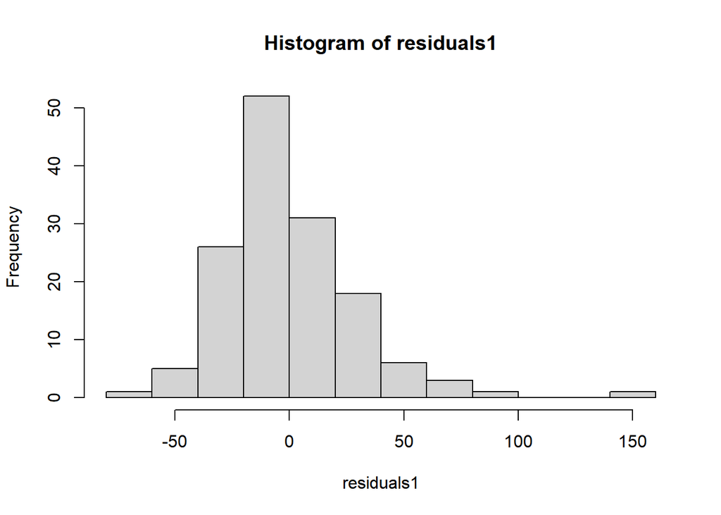

```r
#to analyse residuals to identify bias
residuals1 <- resid(lm1)
hist(residuals1)
```

```r
#A well-fitted model should have residuals that are normally distributed and centered around zero.

#Not that well-fitted
```

#### 4.3.2.3 Model 2 (Air-pollution Variables + Control Variables (Region & Income))

```r
#Model 2
lm2 <-lm(avg_crd_five ~., data = baked_train_subset1)
summary(lm2)
```

```
##
## Call:
## lm(formula = avg_crd_five ~ ., data = baked_train_subset1)
##
## Residuals:
##     Min      1Q  Median      3Q     Max
## -63.254 -10.976  -0.781   9.138  89.806
##
## Coefficients:
##                                   Estimate Std. Error t value Pr(>|t|)
## (Intercept)                        91.7240    18.3978   4.986 1.93e-06 ***
## avg_forest_five                     0.1412     0.0940   1.502 0.135541
## avg_PM_five                         0.2203     0.1626   1.354 0.177992
## avg_smoke_five                      0.5623     0.2592   2.169 0.031893 *
## avg_CO2_five                       -3.1489     0.8807  -3.576 0.000491 ***
## Region_Europe...Central.Asia      -42.2226     6.2058  -6.804 3.37e-10 ***
## Region_Latin.America...Caribbean  -35.3379     7.4512  -4.743 5.47e-06 ***
## Region_Middle.East...North.Africa -32.4062     8.5060  -3.810 0.000214 ***
## Region_North.America              -11.9765    16.8571  -0.710 0.478685
## Region_South.Asia                  40.4167    10.4788   3.857 0.000180 ***
## Region_Sub.Saharan.Africa         -34.1753     7.7406  -4.415 2.10e-05 ***
## income_group_Low.income            27.1569     8.1995   3.312 0.001200 **
## income_group_Lower.Middle.income   14.8170     5.9818   2.477 0.014532 *
## income_group_Upper.Middle.income    3.1111     5.2564   0.592 0.554964
## ---
## Signif. codes:  0 '***' 0.001 '**' 0.01 '*' 0.05 '.' 0.1 ' ' 1
##
## Residual standard error: 21.14 on 130 degrees of freedom
## Multiple R-squared:  0.658,  Adjusted R-squared:  0.6238
## F-statistic: 19.24 on 13 and 130 DF,  p-value: < 2.2e-16
```

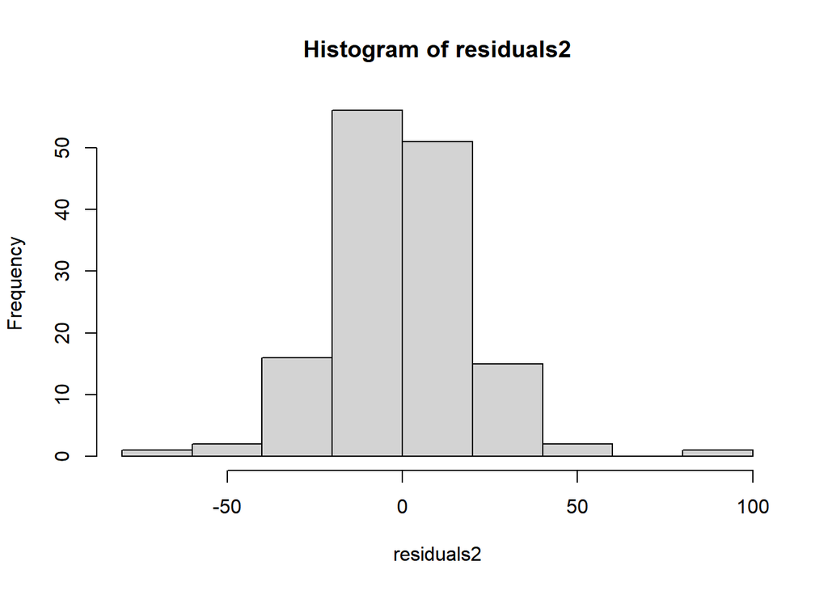

```r
#to analyse residuals to identify bias
residuals2 <- resid(lm2)
hist(residuals2)
```

```r
#A well-fitted model should have residuals that are normally distributed and centered around zero.

#it is centered around zero but have outliers with large numbers
```

### 4.3.3 Blueprint 2 (Log (CRD & CO2))

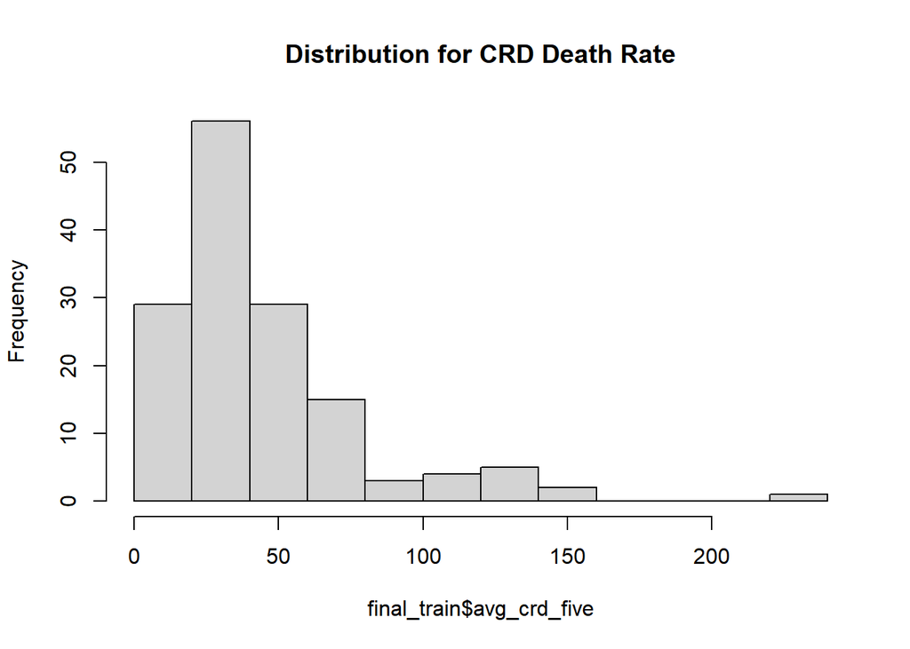

```r
#Distribution of CRD death rate train set using histrogram
hist(final_train$avg_crd_five, main = "Distribution for CRD Death Rate")
```

```r
#Positively skewed
```

```r
#log crd five
final_recipe2 <- recipe(avg_crd_five ~ ., data = final_train) %>%
  step_log(avg_crd_five, avg_CO2_five) %>%      #normalize with a log transformation
  step_impute_median(avg_smoke_five, avg_CO2_five) %>%   #median imputation of NAs
  step_dummy(Region, income_group)

prepare2 <- prep(final_recipe2, training = final_train)

baked_train2 <- bake(prepare2, new_data = final_train)
baked_test2 <- bake(prepare2, new_data = final_test)
```

```r
baked_train2
```

```
## # A tibble: 144 × 16
##    Country        Code  avg_forest_five avg_PM_five avg_smoke_five avg_CO2_five
##    <fct>          <fct>           <dbl>       <dbl>          <dbl>        <dbl>
##  1 Austria        AUT              47.0       13.6            31.2         18.0
##  2 Bahamas, The   BHS              50.9        5.32           10.6         14.6
##  3 Barbados       BRB              14.6       10.5             8.8         14.1
##  4 Bulgaria       BGR              35.3       20.4            40.7         17.7
##  5 Cabo Verde     CPV              11.0       33.4            13.1         13.1
##  6 Croatia        HRV              34.3       18.6            36.1         16.7
##  7 Czech Republic CZE              34.6       17.5            31.4         18.5
##  8 Estonia        EST              55.7        6.75           33.3         16.6
##  9 Finland        FIN              73.7        5.83           24.5         17.6
## 10 France         FRA              30.8       12.2            33.7         19.6
## # ℹ 134 more rows
## # ℹ 10 more variables: avg_crd_five <dbl>, Region_Europe...Central.Asia <dbl>,
## #   Region_Latin.America...Caribbean <dbl>,
## #   Region_Middle.East...North.Africa <dbl>, Region_North.America <dbl>,
## #   Region_South.Asia <dbl>, Region_Sub.Saharan.Africa <dbl>,
## #   income_group_Low.income <dbl>, income_group_Lower.Middle.income <dbl>,
## #   income_group_Upper.Middle.income <dbl>
```

```r
baked_test2
```

```
## # A tibble: 49 × 16
##    Country         Code  avg_forest_five avg_PM_five avg_smoke_five avg_CO2_five
##    <fct>           <fct>           <dbl>       <dbl>          <dbl>        <dbl>
##  1 Afghanistan     AFG              1.85       67.2            26           16.1
##  2 Albania         ALB             28.8        19.0            25.1         15.4
##  3 Algeria         DZA              0.82       22.5            21.1         18.9
##  4 Angola          AGO             55.6        25.0            23.0         17.1
##  5 Antigua and Ba… ATG             19.2         8.89           23.0         13.1
##  6 Australia       AUS             17.3         6.6            15.7         19.8
##  7 Belarus         BLR             42.5        16.5            33           17.9
##  8 Cameroon        CMR             43.6        59.1             8.4         16.1
##  9 Colombia        COL             54.2        17.3             9.9         18.4
## 10 Cyprus          CYP             18.7        15.1            36.4         15.8
## # ℹ 39 more rows
## # ℹ 10 more variables: avg_crd_five <dbl>, Region_Europe...Central.Asia <dbl>,
## #   Region_Latin.America...Caribbean <dbl>,
## #   Region_Middle.East...North.Africa <dbl>, Region_North.America <dbl>,
## #   Region_South.Asia <dbl>, Region_Sub.Saharan.Africa <dbl>,
## #   income_group_Low.income <dbl>, income_group_Lower.Middle.income <dbl>,
## #   income_group_Upper.Middle.income <dbl>
```

```r
cor(baked_train2[c("avg_crd_five", "avg_forest_five", "avg_PM_five", "avg_smoke_five", "avg_CO2_five")])
```

```
##                 avg_crd_five avg_forest_five avg_PM_five avg_smoke_five
## avg_crd_five      1.00000000      0.07618099   0.2187477     0.03022896
## avg_forest_five   0.07618099      1.00000000  -0.4090858     0.02941778
## avg_PM_five       0.21874773     -0.40908578   1.0000000    -0.23608688
## avg_smoke_five    0.03022896      0.02941778  -0.2360869     1.00000000
## avg_CO2_five     -0.31840433     -0.12355890   0.1923055     0.07112904
##                 avg_CO2_five
## avg_crd_five     -0.31840433
## avg_forest_five  -0.12355890
## avg_PM_five       0.19230548
## avg_smoke_five    0.07112904
## avg_CO2_five      1.00000000
```

#### 4.3.3.1 Model 3 (Only Air-pollution Variables)

```r
baked_train_subset2 <- baked_train2[, !colnames(baked_train2) %in% c("Country", "Code")]

lm3 <-lm(avg_crd_five ~ avg_forest_five + avg_PM_five + avg_smoke_five + avg_CO2_five, data = baked_train_subset2)
summary(lm3)
```

```
##
## Call:
## lm(formula = avg_crd_five ~ avg_forest_five + avg_PM_five + avg_smoke_five +
##     avg_CO2_five, data = baked_train_subset2)
##
## Residuals:
##      Min       1Q   Median       3Q      Max
## -1.65553 -0.37130  0.01129  0.42020  1.35791
##
## Coefficients:
##                  Estimate Std. Error t value Pr(>|t|)
## (Intercept)      4.382577   0.363936  12.042  < 2e-16 ***
## avg_forest_five  0.005271   0.002269   2.323   0.0217 *
## avg_PM_five      0.017538   0.003705   4.734 5.37e-06 ***
## avg_smoke_five   0.010266   0.005385   1.907   0.0586 .
## avg_CO2_five    -0.099736   0.019906  -5.010 1.62e-06 ***
## ---
## Signif. codes:  0 '***' 0.001 '**' 0.01 '*' 0.05 '.' 0.1 ' ' 1
##
## Residual standard error: 0.5839 on 139 degrees of freedom
## Multiple R-squared:  0.2296, Adjusted R-squared:  0.2074
## F-statistic: 10.36 on 4 and 139 DF,  p-value: 2.269e-07
```

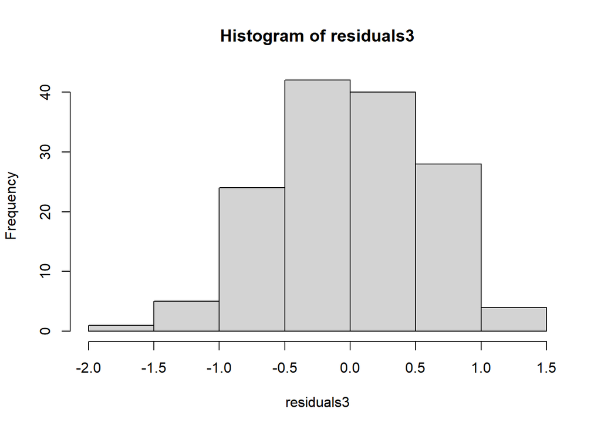

```r
#to analyse residuals to identify bias
residuals3 <- resid(lm3)
hist(residuals3)
```

```r
#A well-fitted model should have residuals that are normally distributed and centered around zero.

#Well-fitted
```

#### 4.3.3.2 Model 4 (Air-pollution Variables + Control Variables (Region & Income))

```r
lm4 <-lm(avg_crd_five ~., data = baked_train_subset2)
summary(lm4)
```

```
##
## Call:
## lm(formula = avg_crd_five ~ ., data = baked_train_subset2)
##
## Residuals:
##      Min       1Q   Median       3Q      Max
## -1.17911 -0.25654  0.03563  0.28595  0.89308
##
## Coefficients:
##                                     Estimate Std. Error t value Pr(>|t|)
## (Intercept)                        4.1531574  0.3598266  11.542  < 2e-16 ***
## avg_forest_five                    0.0008004  0.0018385   0.435 0.664048
## avg_PM_five                        0.0041031  0.0031812   1.290 0.199410
## avg_smoke_five                     0.0067141  0.0050697   1.324 0.187708
## avg_CO2_five                      -0.0369054  0.0172245  -2.143 0.034008 *
## Region_Europe...Central.Asia      -0.8894257  0.1213744  -7.328 2.20e-11 ***
## Region_Latin.America...Caribbean  -0.7035301  0.1457303  -4.828 3.81e-06 ***
## Region_Middle.East...North.Africa -0.6459668  0.1663604  -3.883 0.000163 ***
## Region_North.America              -0.1547895  0.3296927  -0.469 0.639501
## Region_South.Asia                  0.3677295  0.2049455   1.794 0.075093 .
## Region_Sub.Saharan.Africa         -0.4667816  0.1513923  -3.083 0.002501 **
## income_group_Low.income            0.5952785  0.1603657   3.712 0.000304 ***
## income_group_Lower.Middle.income   0.4296357  0.1169919   3.672 0.000350 ***
## income_group_Upper.Middle.income   0.2092294  0.1028046   2.035 0.043862 *
## ---
## Signif. codes:  0 '***' 0.001 '**' 0.01 '*' 0.05 '.' 0.1 ' ' 1
##
## Residual standard error: 0.4134 on 130 degrees of freedom
## Multiple R-squared:  0.6388, Adjusted R-squared:  0.6027
## F-statistic: 17.69 on 13 and 130 DF,  p-value: < 2.2e-16
```

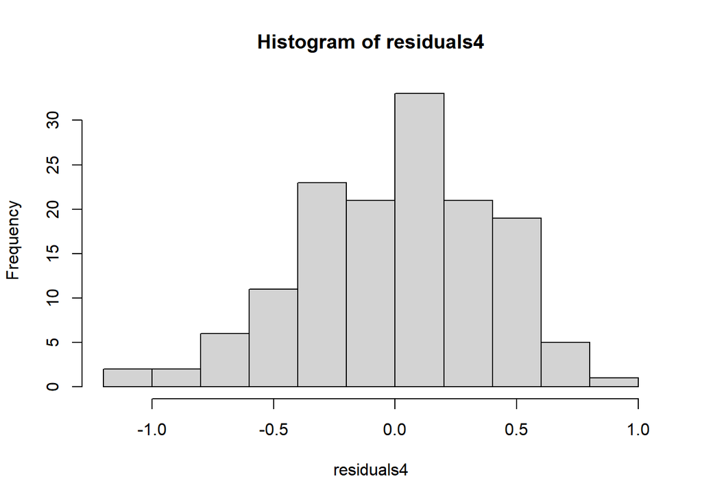

```r
#to analyse residuals to identify bias
residuals4 <- resid(lm4)
hist(residuals4)
```

```r
#A well-fitted model should have residuals that are normally distributed and centered around zero.

#Well-fitted
```

### 4.3.4 Regression Equation

Model 1
$$\hat{Y} = 74.5369 + 0.3713 forest + 0.8957 PM2.5 + 1.0565 smoking -
5.3324 CO2$$

Model 2
$$\hat{Y} = 91.7240 + 0.1412 forest + 0.2203 PM2.5 + 0.5623 smoking -
3.1489 CO2-42.2226 ECA -35.3379 LAC-32.4062 MENA - 11.9765 NA + 40.4167
SA - 34.1753SSA+ 27.1569 Low +14.8170 LoM +3.1111 UpM$$

Model 3
$$\hat{Y} = 4.3826 + 0.0053 forest + 0.0175 PM2.5 + 0.0103 smoking -
0.0997 CO2$$

Model 4
$$\hat{Y} = 4.1532+ 0.0008forest +
0.0041PM2.5 + 0.0067smoking - 0.0369CO2-0.8894ECA -0.7035LAC-0.6460MENA
- 0.1548NA + 0.3677SA - 0.4668SSA + 0.5953 Low +0.4296 LoM +0.2092UpM$$

### 4.3.5 Combining Regression Output for 4 MLR models

```r
finaltb <- list(lm1, lm2, lm3, lm4)

library(tibble) #specific the header columns

rows <- tribble(~term, ~'Model 1', ~'Model 2', ~'Model 3', ~'Model 4',
                '(East Asia & Pacific = 0)', '', '', '', '')

attr(rows, 'position') <- c(11)
```

```r
library(modelsummary)
library(huxtable)

finaltb_lm <- modelsummary(finaltb,
             output = "huxtable",
             fmt = 4,
             esimate = "{estimate}{stars}",
             statistics = "std.error",
             stars = TRUE,
             gof_omit = 'AIC|BIC|RMSE|Log.Lik.|FE',
             add_rows = rows,
             coef_rename = c("(Intercept)" = "Constant",
               "avg_forest_five" = "Forest area (% of land area)",
                             "avg_PM_five" = "Concentration of fine particulate matter (PM2.5)",
                             "avg_smoke_five" = "Share of adults smoking",
                             "avg_CO2_five" = "CO2 emission",
                             "Region_Europe...Central.Asia" = "Europe & Central Asia",
                             "Region_Latin.America...Caribbean" = "Latin America & Caribbean",
                             "Region_Middle.East...North.Africa" = "Middle East & North America",
                             "Region_North.America" = "North America",
                             "Region_South.Asia" = "South Asia",
                             "Region_Sub.Saharan.Africa" = "Sub Saharan Africa",
                             "income_group_Low.income" = "(High income = 0) Low income",
                             "income_group_Lower.Middle.income" = "Lower-middle income",
                             "income_group_Upper.Middle.income" = "Upper-middle income"))


finaltb_lm
```

|  | (1) | (2) | (3) | (4) |
| --- | --- | --- | --- | --- |
| Constant | 74.5369*** | 91.7240*** | 4.3826*** | 4.1532*** |
|  | (18.5686) | (18.3978) | (0.3639) | (0.3598) |
| Forest area (% of land area) | 0.3713** | 0.1412 | 0.0053* | 0.0008 |
|  | (0.1158) | (0.0940) | (0.0023) | (0.0018) |
| Concentration of fine particulate matter (PM2.5) | 0.8957*** | 0.2203 | 0.0175*** | 0.0041 |
|  | (0.1890) | (0.1627) | (0.0037) | (0.0032) |
| Share of adults smoking | 1.0565*** | 0.5623* | 0.0103+ | 0.0067 |
|  | (0.2747) | (0.2592) | (0.0054) | (0.0051) |
| CO2 emission | -5.3324*** | -3.1489*** | -0.0997*** | -0.0369* |
|  | (1.0156) | (0.8807) | (0.0199) | (0.0172) |
| (East Asia & Pacific = 0) |  |  |  |  |
| Europe & Central Asia |  | -42.2226*** |  | -0.8894*** |
|  |  | (6.2058) |  | (0.1214) |
| Latin America & Caribbean |  | -35.3379*** |  | -0.7035*** |
|  |  | (7.4512) |  | (0.1457) |
| Middle East & North America |  | -32.4062*** |  | -0.6460*** |
|  |  | (8.5060) |  | (0.1664) |
| North America |  | -11.9765 |  | -0.1548 |
|  |  | (16.8571) |  | (0.3297) |
| South Asia |  | 40.4167*** |  | 0.3677+ |
|  |  | (10.4788) |  | (0.2049) |
| Sub Saharan Africa |  | -34.1753*** |  | -0.4668** |
|  |  | (7.7406) |  | (0.1514) |
| (High income = 0) Low income |  | 27.1569** |  | 0.5953*** |
|  |  | (8.1995) |  | (0.1604) |
| Lower-middle income |  | 14.8170* |  | 0.4296*** |
|  |  | (5.9818) |  | (0.1170) |
| Upper-middle income |  | 3.1111 |  | 0.2092* |
|  |  | (5.2564) |  | (0.1028) |
| Num.Obs. | 144 | 144 | 144 | 144 |
| R2 | 0.274 | 0.658 | 0.230 | 0.639 |
| R2 Adj. | 0.253 | 0.624 | 0.207 | 0.603 |
| F | 13.090 | 19.240 | 10.357 | 17.687 |
| + p < 0.1, * p < 0.05, ** p < 0.01, *** p < 0.001 |  |  |  |  |

### 4.3.6 Assessing model accuracy

```r
# Train model using 10-fold cross-validation
set.seed(123)  # for reproducibility
(cv_lm1 <- train(
  form = avg_crd_five ~ avg_forest_five + avg_PM_five + avg_smoke_five + avg_CO2_five,
  data = baked_train_subset1,
  method = "lm",
  trControl = trainControl(method = "cv", number = 10)
))
```

```
## Linear Regression
##
## 144 samples
##   4 predictor
##
## No pre-processing
## Resampling: Cross-Validated (10 fold)
## Summary of sample sizes: 128, 129, 129, 130, 128, 131, ...
## Resampling results:
##
##   RMSE      Rsquared   MAE
##   28.83247  0.2428322  21.9743
##
## Tuning parameter 'intercept' was held constant at a value of TRUE
```

```r
# Train model using 10-fold cross-validation
set.seed(123)  # for reproducibility
(cv_lm2 <- train(
  form = avg_crd_five ~ .,
  data = baked_train_subset1,
  method = "lm",
  trControl = trainControl(method = "cv", number = 10)
))
```

```
## Linear Regression
##
## 144 samples
##  13 predictor
##
## No pre-processing
## Resampling: Cross-Validated (10 fold)
## Summary of sample sizes: 128, 129, 129, 130, 128, 131, ...
## Resampling results:
##
##   RMSE      Rsquared   MAE
##   22.15411  0.6279125  16.45442
##
## Tuning parameter 'intercept' was held constant at a value of TRUE
```

```r
# Train model using 10-fold cross-validation
set.seed(123)  # for reproducibility
(cv_lm3 <- train(
  form = avg_crd_five ~ avg_forest_five + avg_PM_five + avg_smoke_five + avg_CO2_five,
  data = baked_train_subset2,
  method = "lm",
  trControl = trainControl(method = "cv", number = 10)
))
```

```
## Linear Regression
##
## 144 samples
##   4 predictor
##
## No pre-processing
## Resampling: Cross-Validated (10 fold)
## Summary of sample sizes: 128, 129, 129, 130, 128, 131, ...
## Resampling results:
##
##   RMSE       Rsquared   MAE
##   0.5852235  0.2256553  0.4798632
##
## Tuning parameter 'intercept' was held constant at a value of TRUE
```

```r
# Train model using 10-fold cross-validation
set.seed(123)  # for reproducibility
(cv_lm4 <- train(
  form = avg_crd_five ~ .,
  data = baked_train_subset2,
  method = "lm",
  trControl = trainControl(method = "cv", number = 10)
))
```

```
## Linear Regression
##
## 144 samples
##  13 predictor
##
## No pre-processing
## Resampling: Cross-Validated (10 fold)
## Summary of sample sizes: 128, 129, 129, 130, 128, 131, ...
## Resampling results:
##
##   RMSE       Rsquared   MAE
##   0.4293212  0.5814052  0.3464413
##
## Tuning parameter 'intercept' was held constant at a value of TRUE
```